# Red Wine Quality

Arpit Kanodia

August 14, 2015

## About the Project

In this project, I will explore the quality of wine wrt different properties and chemicals. I will produce the different plots, tables and numeric stats value for finally defining the results.

The data wineQualityReds.csv is available on this link [wineQualityReds.csv](https://www.google.com/url?q=https://s3.amazonaws.com/udacity-hosted-downloads/ud651/wineQualityReds.csv&sa=D&usg=AFQjCNFDGQM6iS1viDgkVnXfjlJUymYerA)

And the details about the data is available here [Text file about Details of Data](https://s3.amazonaws.com/udacity-hosted-downloads/ud651/wineQualityInfo.txt)

## Basic Details about the Dataset

Lets examine the structure and schema of dataset

```
## 'data.frame':    1599 obs. of  13 variables:
##  $ X                   : int  1 2 3 4 5 6 7 8 9 10 ...
##  $ fixed.acidity       : num  7.4 7.8 7.8 11.2 7.4 7.4 7.9 7.3 7.8 7.5 ...
##  $ volatile.acidity    : num  0.7 0.88 0.76 0.28 0.7 0.66 0.6 0.65 0.58 0.5 ...
##  $ citric.acid         : num  0 0 0.04 0.56 0 0 0.06 0 0.02 0.36 ...
##  $ residual.sugar      : num  1.9 2.6 2.3 1.9 1.9 1.8 1.6 1.2 2 6.1 ...
##  $ chlorides           : num  0.076 0.098 0.092 0.075 0.076 0.075 0.069 0.065 0.073 0.071 ...
##  $ free.sulfur.dioxide : num  11 25 15 17 11 13 15 15 9 17 ...
##  $ total.sulfur.dioxide: num  34 67 54 60 34 40 59 21 18 102 ...
##  $ density             : num  0.998 0.997 0.997 0.998 0.998 ...
##  $ pH                  : num  3.51 3.2 3.26 3.16 3.51 3.51 3.3 3.39 3.36 3.35 ...
##  $ sulphates           : num  0.56 0.68 0.65 0.58 0.56 0.56 0.46 0.47 0.57 0.8 ...
##  $ alcohol             : num  9.4 9.8 9.8 9.8 9.4 9.4 9.4 10 9.5 10.5 ...
##  $ quality             : int  5 5 5 6 5 5 5 7 7 5 ...
```

```
##        X          fixed.acidity   volatile.acidity  citric.acid
##  Min.   :   1.0   Min.   : 4.60   Min.   :0.1200   Min.   :0.000
##  1st Qu.: 400.5   1st Qu.: 7.10   1st Qu.:0.3900   1st Qu.:0.090
##  Median : 800.0   Median : 7.90   Median :0.5200   Median :0.260
##  Mean   : 800.0   Mean   : 8.32   Mean   :0.5278   Mean   :0.271
##  3rd Qu.:1199.5   3rd Qu.: 9.20   3rd Qu.:0.6400   3rd Qu.:0.420
##  Max.   :1599.0   Max.   :15.90   Max.   :1.5800   Max.   :1.000
##  residual.sugar     chlorides       free.sulfur.dioxide
##  Min.   : 0.900   Min.   :0.01200   Min.   : 1.00
##  1st Qu.: 1.900   1st Qu.:0.07000   1st Qu.: 7.00
##  Median : 2.200   Median :0.07900   Median :14.00
##  Mean   : 2.539   Mean   :0.08747   Mean   :15.87
##  3rd Qu.: 2.600   3rd Qu.:0.09000   3rd Qu.:21.00
##  Max.   :15.500   Max.   :0.61100   Max.   :72.00
##  total.sulfur.dioxide    density             pH          sulphates
##  Min.   :  6.00       Min.   :0.9901   Min.   :2.740   Min.   :0.3300
##  1st Qu.: 22.00       1st Qu.:0.9956   1st Qu.:3.210   1st Qu.:0.5500
##  Median : 38.00       Median :0.9968   Median :3.310   Median :0.6200
##  Mean   : 46.47       Mean   :0.9967   Mean   :3.311   Mean   :0.6581
##  3rd Qu.: 62.00       3rd Qu.:0.9978   3rd Qu.:3.400   3rd Qu.:0.7300
##  Max.   :289.00       Max.   :1.0037   Max.   :4.010   Max.   :2.0000
##     alcohol         quality
##  Min.   : 8.40   Min.   :3.000
##  1st Qu.: 9.50   1st Qu.:5.000
##  Median :10.20   Median :6.000
##  Mean   :10.42   Mean   :5.636
##  3rd Qu.:11.10   3rd Qu.:6.000
##  Max.   :14.90   Max.   :8.000
```

As our main goal of this project is quality, it will be intresting to see statistics of only quality.

```
##  int [1:1599] 5 5 5 6 5 5 5 7 7 5 ...
```

```
##    Min. 1st Qu.  Median    Mean 3rd Qu.    Max.
##   3.000   5.000   6.000   5.636   6.000   8.000
```

Some initial basic details of the dataset are observed as following:

- There are 1599 obs. with 13 variables.
- From the literature, the value of `quality` is in range of 0-10, and was rated by atleast 3 whine experts. In the dataset value range from 3-8, with median of 6 and mean at 5.636.
- `X` appears to be a identifier for each data.

## Plots of Single Variables

Just to explore the data visully, I’ll draw all the graphs for 12 variables quickly. The motive behind to see the distribution. Histograms are required to analyze initially about the distribution of the different variables.

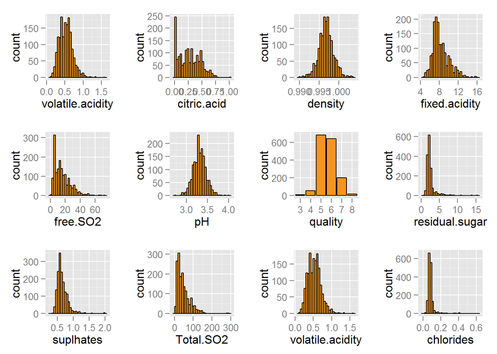

## Analysis of Single Variable

## Quality of the Wine

The quality of wine is in discrete value range from 0-10 as mentioned in description text of dataset. but with graph of quality one can definetely see the quality is in between 3-8, where as most of the data lie between 5-7, with very small data at 3,4 and at 8.

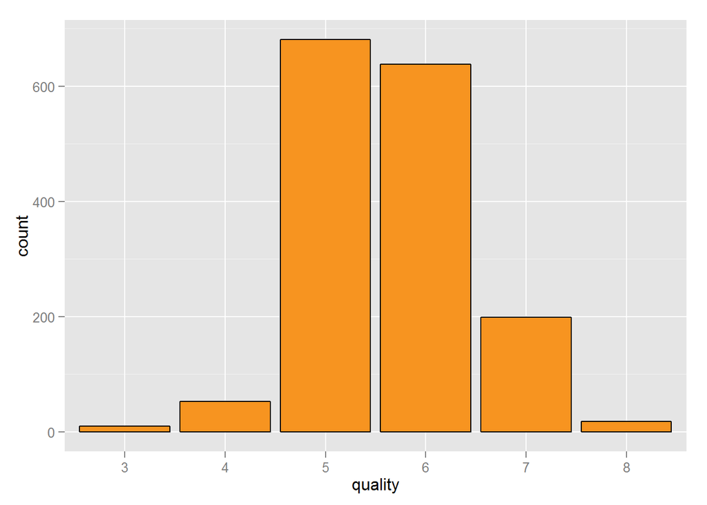

For rating of wine, I thought to divide the quality into ‘bad’,‘average’, ‘good’ and ‘very good’. As the data range only from 3-8, dividing the data into 4 parameters, whereas ‘very good’ is non existent as there are no data for 9 and 10, is nonsensical. I finally decided to divide the data into only 3 parameters ‘bad’, ‘average’ and ‘good’.

```
##     bad average    good
##      63    1319     217
```

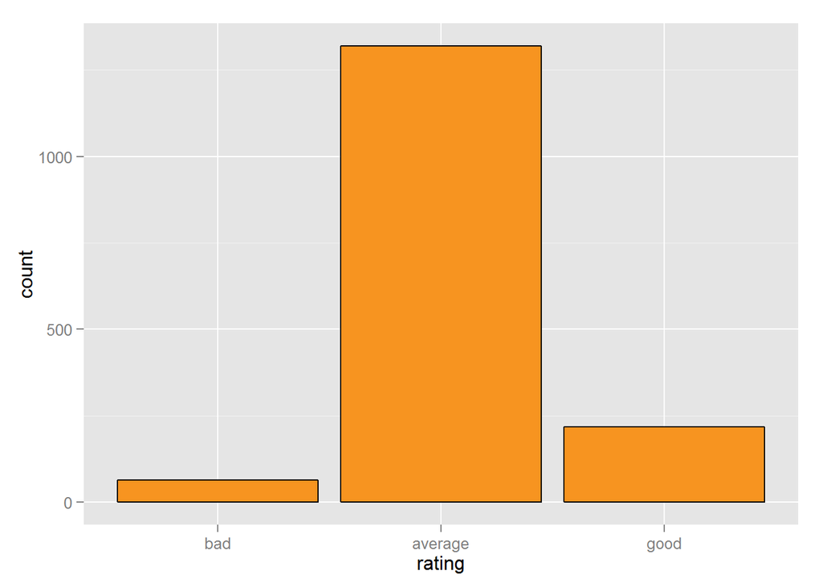

## Analysis of Distribution

- It is obviously appearing in graphs that maybe pH and density are normally distributed. -`Sulphur dioxide`,`sulphates`,`alcohol`, `fixed and volatile acidity` looks like to be long tailed.
- Residual sugar and chlorides have a extreme outliers.
- Citric acid seems to have large number of zero values.

#### Log based Plots

To furthur analyze the distribution, log10 based transformation is required.

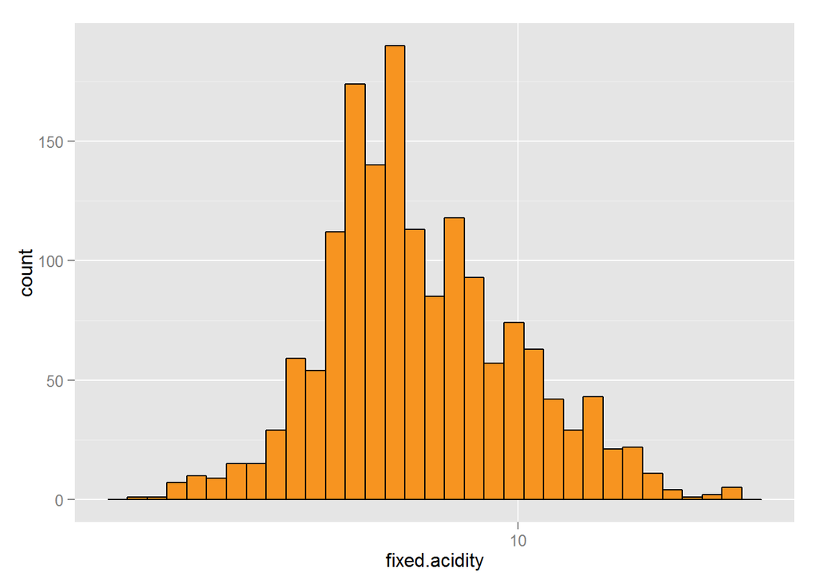

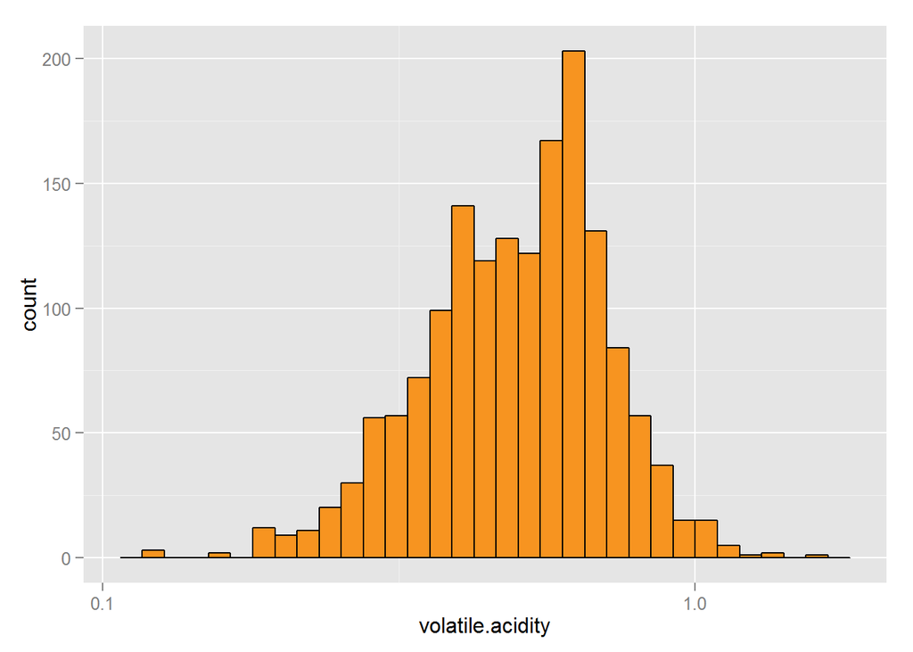

- It looks like the `log(fixed.acidity)` and `log(volatile.acidity)` atleast are more bell-shaped than normal plots.

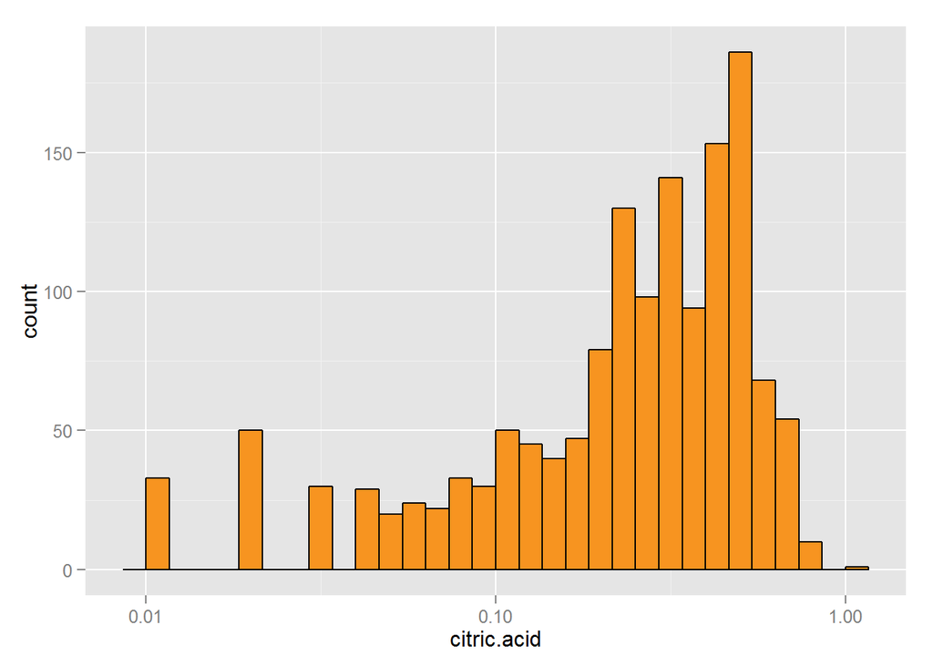

When plots are made on the base of log 10, `fixed.acidity` and `volatile.acidity` appeared to be normally distributed, as the pH is normally distributed which is measure of acidity in log scale. But, `citric.acid` not appeared to be normally distributed. On furthur observations.

```
## [1] 132
```

This is clear that 132 observations are actually zero.

- For furthur investigation, in normal histograms `residual.sugar`, `sulphates` and `chlorides` seems to be highly right skewed.

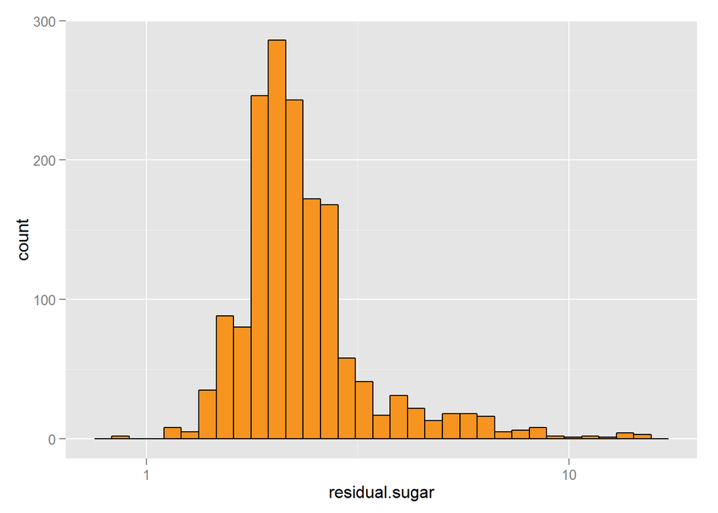

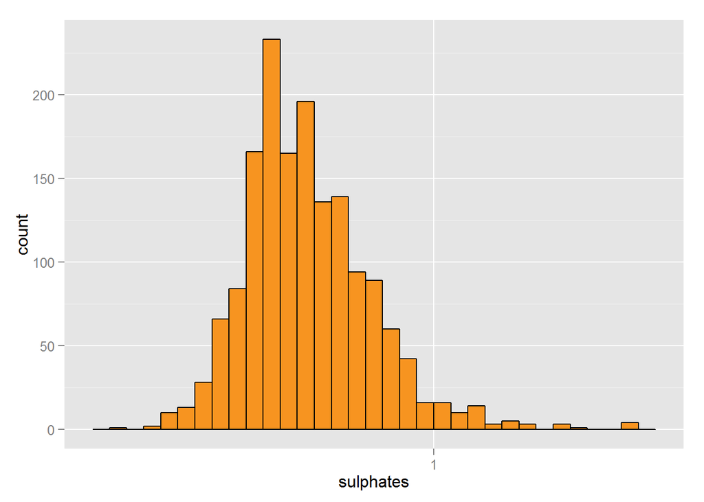

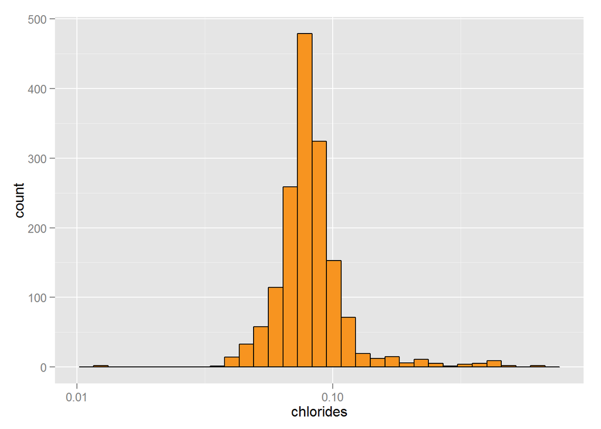

- After log transformation `residual.sugar`, `sulphates` and `chlorides` looks in bell shape and normally distributed.

## Checking the Overall picture of Dataset

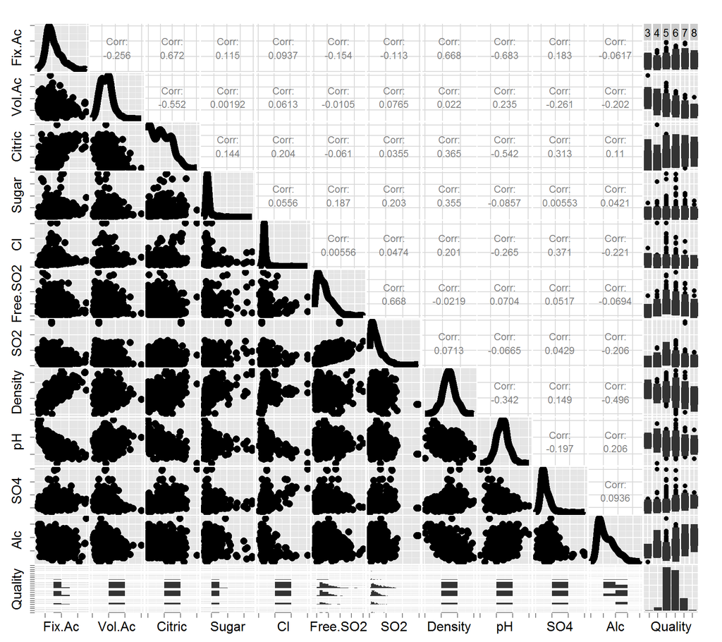

- A strong correlation found in fixed.acidity and pH.
- A high correlation in volatile acidity and citric.
- A strong correlation between free.SO2 and SO2
- A strong correlation exist between fixed.acidity and Density.

## Some Short Questions

#### Did you create any new variables from existing variables in the dataset?

Yes, `rating` based on quality is created that is bad,average and good wine. In last plot I also created `AlcohalRating` according to % of Alcohol in Wine.

Furthur I created a new variable for acidity, it seems like `fixed.acidity` and `volatile.acidity` caused because of different acids in the Wine. I created a new `Total.acidity` containing the sum of `fixed.acidity`,`volatile.acidity` and `citric.acidity`.

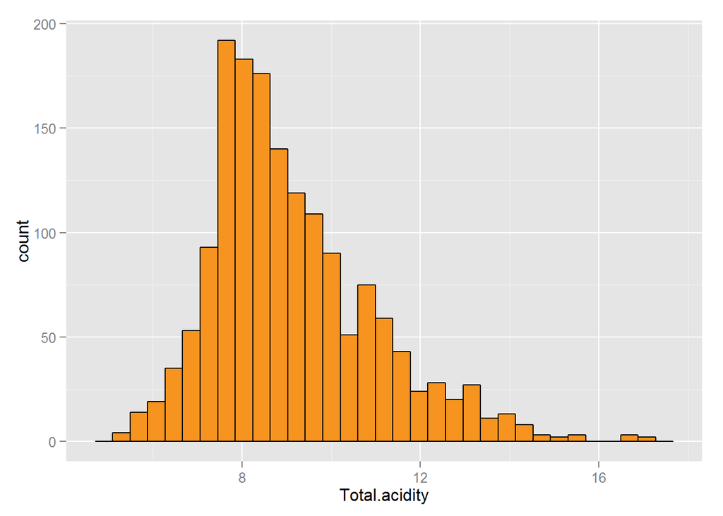

I searched on internet and I found fixed acidity caused because of tartaric, malic, citric, and succinic acids in wine. And volatile acidity causes because of acetic acid.

Source:

[Fixed Acidity](http://waterhouse.ucdavis.edu/whats-in-wine/fixed-acidity) [Volatile Acidity](http://waterhouse.ucdavis.edu/whats-in-wine/volatile-acidity)

#### Of the features you investigated, were there any unusual distributions? Did you perform any operations on the data to tidy, adjust, or change the form of the data? If so, why did you do this?

I investigated the distribution in above sections. For outliers I decided to plot the boxplots. In Single Variable plot, I didnt tidy or adjust the data, but plotted some on log scale.

#### Boxplots of Single Variable

For defining the median across `quality` and `rating` it is required to plot the Boxplot.

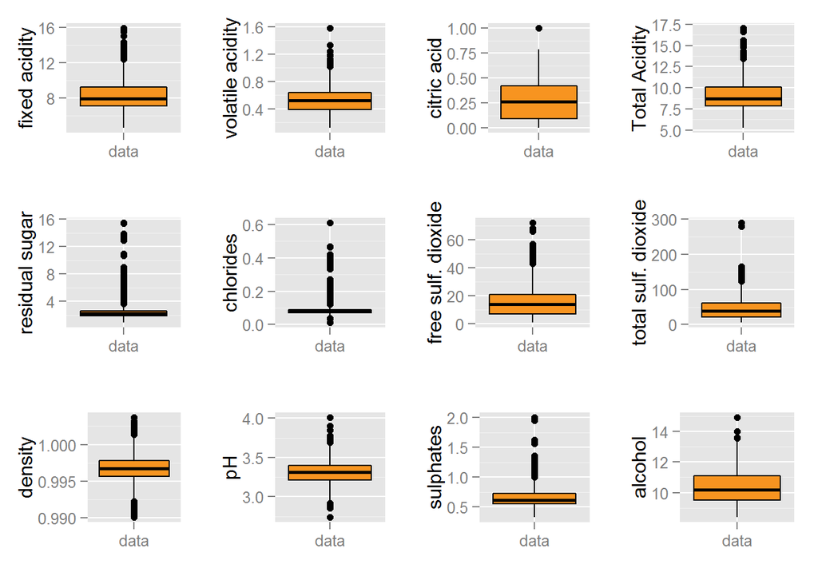

#### Mean

```
##    fixed.acidity volatile.acidity      citric.acid    Total.acidity
##       8.31963727       0.52782051       0.27097561       9.11843340
##   residual.sugar        chlordies         free.SO2        total.SO2
##       2.53880550       0.08746654      15.87492183      46.46779237
##          density               pH        sulphates          alcohol
##       0.99674668       3.31111320       0.65814884      10.42298311
```

#### Median

```
##    fixed.acidity volatile.acidity      citric.acid    Total.acidity
##          7.90000          0.52000          0.26000          8.72000
##   residual.sugar        chlordies         free.SO2        total.SO2
##          2.20000          0.07900         14.00000         38.00000
##          density               pH        sulphates          alcohol
##          0.99675          3.31000          0.62000         10.20000
```

#### Boxplots for Two variable (Quality V/S Different Variables)

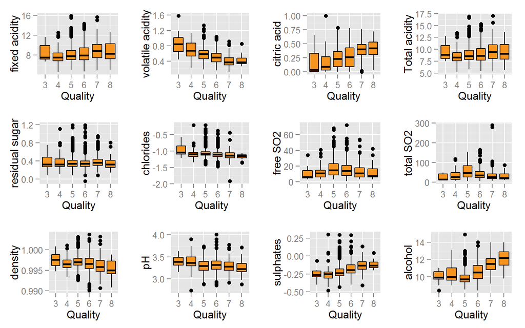

#### Boxplots for Two variable (Rating V/S Different Variables)

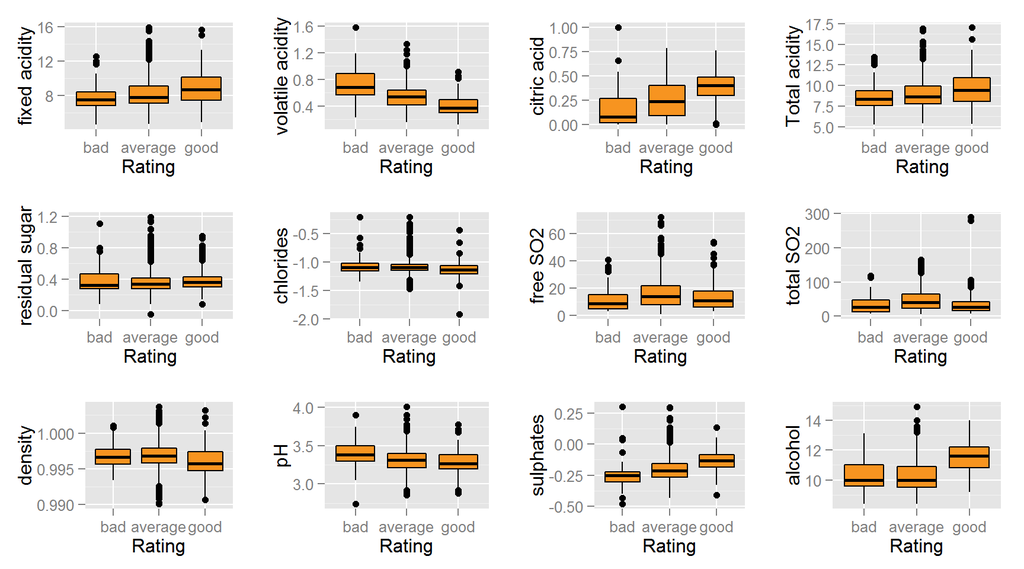

#### Analysis of Boxplots

By examining the plots, some conclusions can be drawn:

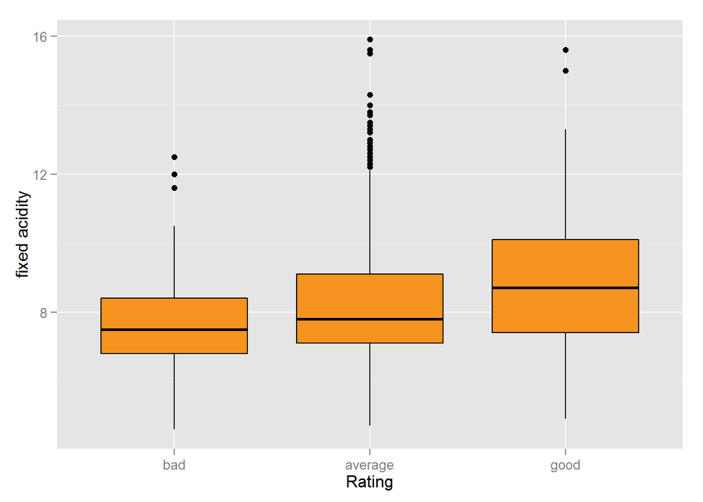

```
##     bad average    good
##     7.5     7.8     8.7
```

- A `good` wine causes because of high `fixed.acidity` (tartaric, malic, citric, and succinic acids).

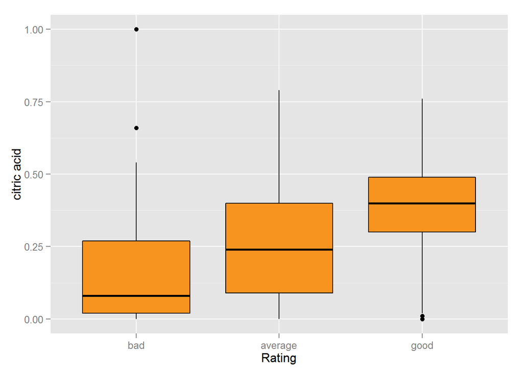

```
##     bad average    good
##    0.08    0.24    0.40
```

- A `good` wine causes because of high `citric.acid`.

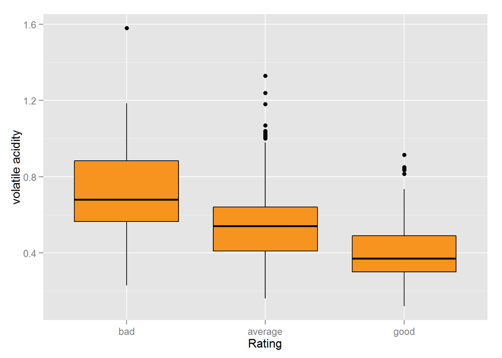

```
##     bad average    good
##    0.68    0.54    0.37
```

- A `good` wine causes because of low `volatile.acidity`(acetic acid).

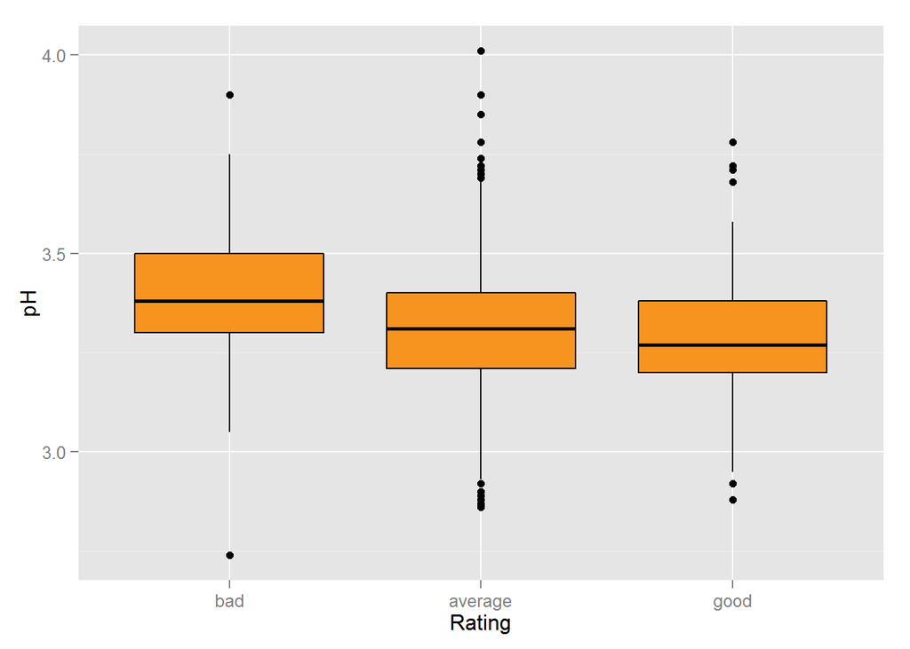

```
##     bad average    good
##    3.38    3.31    3.27
```

- A `good` wine causes because of lower `pH` value, means higher acidity.

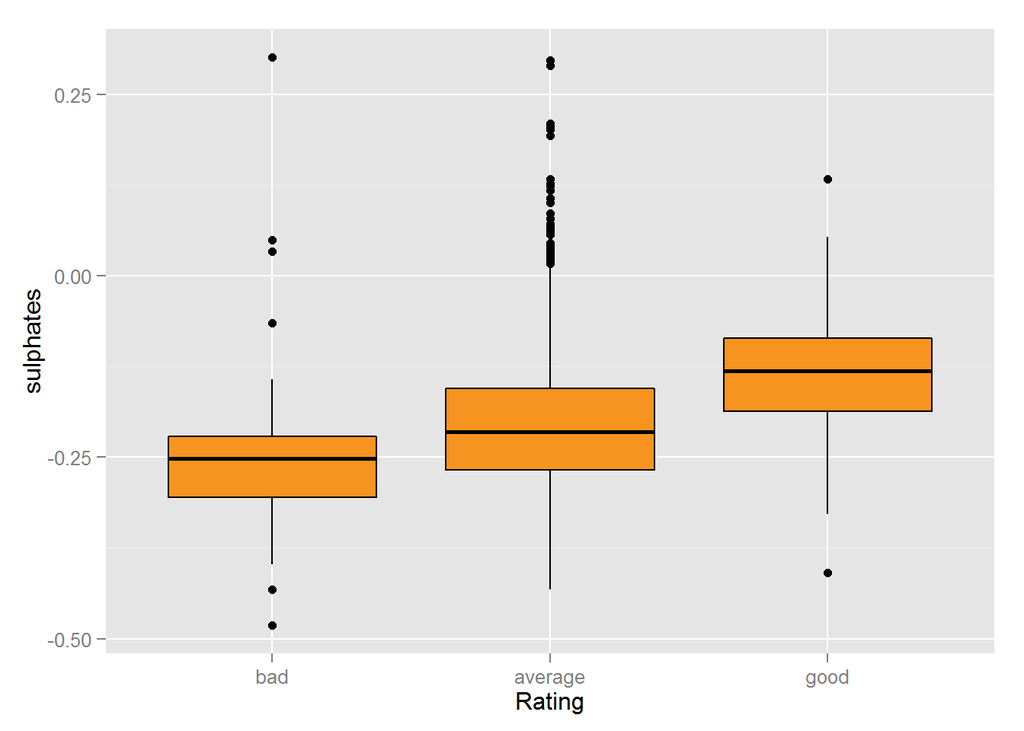

```
##        bad    average       good
## -0.2518120 -0.2146702 -0.1307683
```

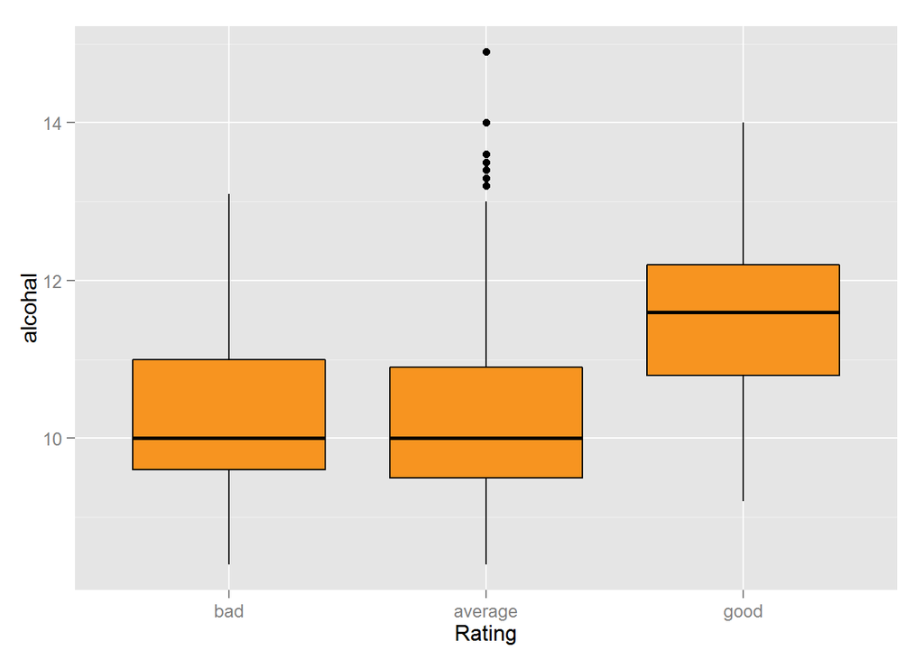

```
##     bad average    good
##    10.0    10.0    11.6
```

- A `good` wine causes because of higher `alcohal`.
- Little bit, lesser `chlorides` and `density` also affect the wine quality.
- `SO2` and `Residual Sugar` donot seems to have any affect on wine quality.

#### Correlation in between Quality and Different Variables

```
##        fixed.acidity     volatile.acidity          citric.acid
##           0.12405165          -0.39055778           0.22637251
##        Total.acidity log10.residual.sugar      log10.chlordies
##           0.10375373           0.02353331          -0.17613996
##             free.SO2            total.SO2              density
##          -0.05065606          -0.18510029          -0.17491923
##                   pH      log10.sulphates              alcohol
##          -0.05773139           0.30864193           0.47616632
```

Strong Correlation found in quality and

- Alcohal
- Volatile Acidity
- Log10 of Sulphates
- Citric Acid

Definetely Alcohal, Volatile Acidity, Log10 of Sulphates and Citric acid are the main parameters that affecting the quality of wine.

#### Scatter Plot

To graphically check the correlation and the represent the relatationship graphically, it required to plot the Scatter plot.

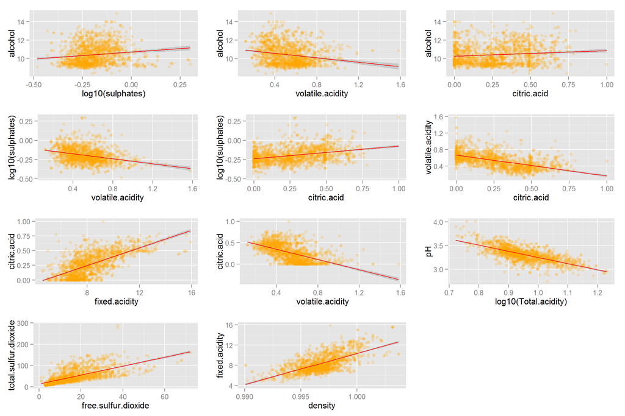

```
##          log10(Sulphates) v/s Alcohol
##                             0.1351562
##          volatile.acidity v/s Alcohol
##                            -0.2022880
## volatile.acidity v/s log10(sulphates)
##                            -0.3005487
##     citric.acid v/s log10 (sulphates)
##                             0.3315162
##       citric.acid vs volatile.acidity
##                            -0.5524957
##         fixed.acidity v/s citric.acid
##                             0.6717034
##      volatile.acidity v/s citric.acid
##                            -0.5524957
##                  Total.acidity v/s pH
##                            -0.7044435
##                free SO2 v/s Total SO2
##                             0.6724531
##             Density v/s Fixed.Acidity
##                             0.6678044
```

I found very strong correlation between `Total.acidity` and `pH`, and the strongest correlation after that is between `free.SO2` and `total.SO2`.

This is obvious that the strong correlation found in Acidity and pH because of pH is inversely proportional to acidity. One question need to ask what other components affecting pH other than acids. We can see this difference by building a linear model.

There is also a strong correlation between `fixed.acidity` and `density`. Maybe the density in the wine mainty causes because of fixed.acidity.

#### Errors in between Observerd pH and Predictive pH

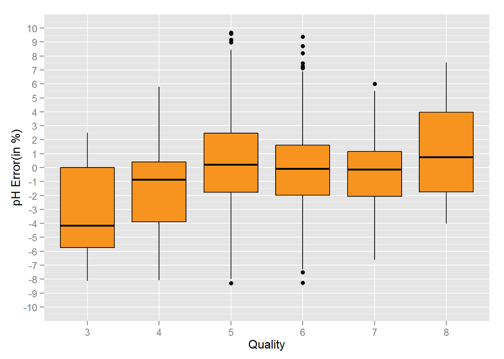

The median % error in all cases remain somewhere close to 0 except in quality of 3. The median % of error of quality of 3 is at slightly lower than negative 4%. In this case we can conclude, the acids are not performing well in this case, or error is caused because of impurity in Acids.

# Summary and Plots

## Effect of acids on Wine

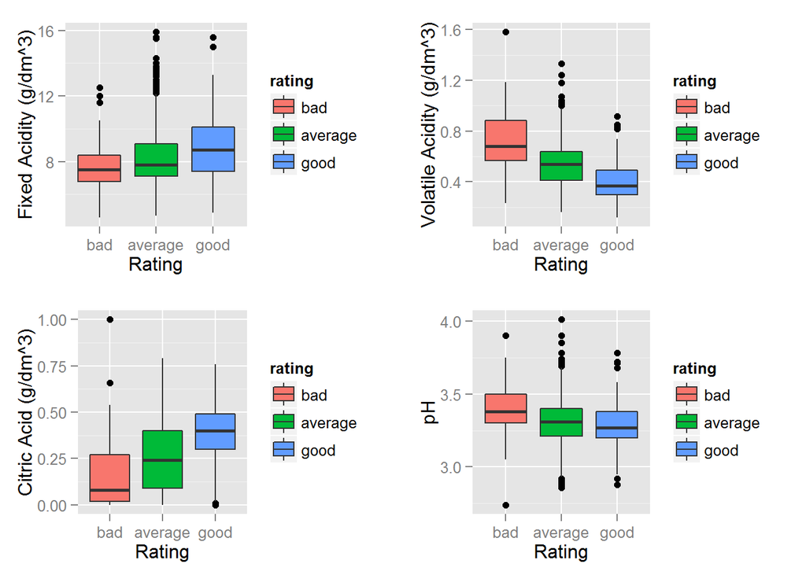

## What is the actual difference in Bad and Good Wine

To understand this, I removed `average` rating from plot.

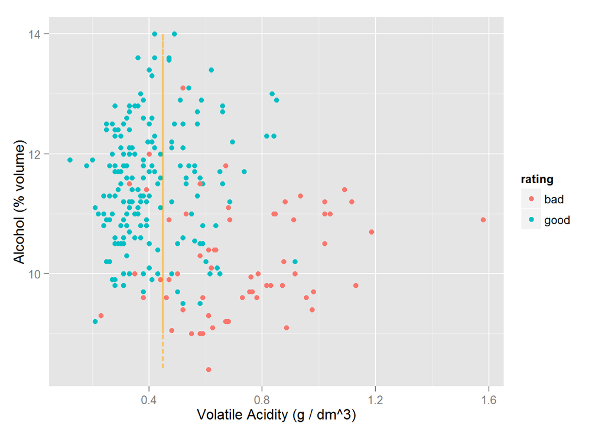

- From this plot, this can be concluded the `good` wine creating a cluster when quantity of volatile.acidity is low and quantity of alcohal is high compare to `bad` wine (except some cases).
- The best way to make a `good` wine can be keeping volatile.acidity low and keeping alcohol high.

## Histogram Based on % Volume of Alcohol

```
##      Low Moderate     High
##      297     1140      162
```

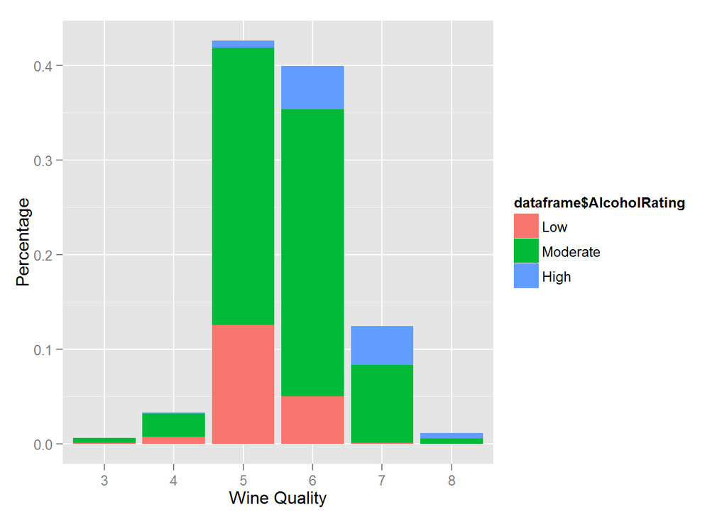

For plotting this, I divided the data into 3 section according to % of Alcohol according to this

- `Low` with less than 9.5%
- `Moderate` with inbetween 9.5 and 12%
- `High` above 12%.

I found as the quality increases, the % of alcohal also increases. The number of wine with `Low` % of alcohol vanished as Wine Quality increases.

# Summary

The findings for `Good` Wine as follows.

# Final Reflection

I was able to determine which factor affect the wine quality most i.e alcohol, sulphates and acidity. Important note is that quality or rating is subjective manner, and can change from person to person. The above graphs described what makes a wine `good`.

I never done the statistical analysis from boxplot before, it took me time to understand the boxplot.

This is possible the dataset is old, or dataset is made from old parameters of wine. I furthur faced many problems in many functions of R, as is grid.arrange and in creating functions. I pretty worked hard in understanding this in [stackoverflow](http://stackoverflow.com/).

On other note, the dataset is from which country is not defined. The various parameters defined differently in different country. Demographically and ethinically, a wine which is `bad` for one maybe `good` for other. For example, a French can rate a wine as `good` but a person from US maybe rate the same wine as `bad`.

## Future Analysis

- Future Analysis can be done by sub-classification is `residual.sugar` in `sweet wine` and `dry wine`. [Wikipedia](http://en.wikipedia.org/wiki/Sweetness_of_wine#Residual_sugar)
- Furthur examination of outliers.
- Rating and Quality based on region.